# **Deterministic Production Planning**

Merchandise is part of the streaming platform IP ecosystem. Since it is closely connected to the limited lifetime of a movie or TV series, we will optimize the production plan to maximize the profit. This is a deterministic production planning problem. Based on the market data, we will determine the production schedule to maximize total profit.

**Objective function:**

$$\text{Max profit} = \text{Max}\sum_{i}{ \text{(revenue} - \text{prodction cost} - \text{storage cost} - \text{shortage cost})_{i}}$$

**Decision Variables:**

```
                                                            Pro(i): Production quantity of phase i.

                                                            Inv(i): Inventory of phase i.

                                                            Short(i): Shortage of phase i.

                                                            Sales(i): Sales of phase i.

                                                            Bk_Sales(i): Backorder Sales of phase i.
```

**Constraints:**

$$\text{Pro}_{i} \leq \text{Maximum production quantity}$$ $$\text{Sales}_{i} \leq \text{Demand}_{i}$$ $$\text{Sales}_{i} + \text{Short}_{i} = \text{Demand}_{i}$$

$$\text{Bk$$_$$Sales}_{i} \leq \text{Short}_{i-1}$$

$$\text{Sales}_{i} + \text{Bk$$_$$Sales}_{i} \leq \text{Inv}_{i-1} + \text{Pro}_{i}$$

$$\text{Inv}_{i} = \text{Inv}_{i-1} + \text{Pro}_{i} - \text{Sales}_{i} - \text{Bk$$_$$Sales}_{i}$$

```python
import pandas as pd
import pulp
import matplotlib.pyplot as plt

# demand of each phases of the movie or TV series lifecycle.
phases = ["beginning", "middle", "ending"]
demand = {"beginning": 2000, "middle": 150000, "ending": 10000}

model = pulp.LpProblem("Max_profit_Optimization", pulp.LpMaximize)

production_cost = 20
storage_cost = 5
shortage_cost = 39

price = 100
max_production_quantity = 70000

# Decision Variables
# Production quantity of each phase.
Pro = pulp.LpVariable.dicts("Production", phases, lowBound=0, cat='Integer')

# Inventory of each phase.
Inv = pulp.LpVariable.dicts("Inventory", phases, lowBound=0, cat='Integer')

# Shortage of each phase.
Short = pulp.LpVariable.dicts("Shortage", phases, lowBound=0, cat='Integer')

# Sales of each phase.
Sales = pulp.LpVariable.dicts("Sales", phases, lowBound=0, cat='Integer')

# Backorder Sales of each phase.
Bk_Sales = pulp.LpVariable.dicts("Backorder_Sales", phases, lowBound=0, cat='Integer')


# Objective Function
# profit = revenue - prodction cost - storage cost - shortage cost.
model += pulp.lpSum(
   ((Sales[i] + Bk_Sales[i]) * price) - (Pro[i] * production_cost) -
    (Inv[i] * storage_cost) - (Short[i] * shortage_cost)
    for i in phases)

# Constraints
for index, i in enumerate(phases):
    # 1. Production quantity <= Maximum production quantity
    model += Pro[i] <= max_production_quantity
    # 2. Sales <= Demand
    model += Sales[i] <= demand[i]
    # 3. Sales + Shortage = Demand
    model += Sales[i] + Short[i] == demand[i]
    # 4. Backorder Sales <= Shortage of last phase
    if index == 0:
        model += Bk_Sales[i] == 0
    else:
        model += Bk_Sales[i] <= Short[phases[index-1]]
    # 5. Sales + Backorder Sales <= Inventory of last phase + Production quantity of current phase
    if index == 0:
        model += Sales[i] <= Pro[i]
    else:
        model += Sales[i] + Bk_Sales[i] <= Inv[phases[index-1]] + Pro[i]
    # 6. Inventory = Inventory of last phase + Production quantity - Sales - Backorder Sales
    if index == 0:
        model += Inv[i] == Pro[i] - Sales[i]
    else:
        model += Inv[i] == Inv[phases[index-1]] + Pro[i] - Sales[i] - Bk_Sales[i]

# solve problem
model.solve(pulp.PULP_CBC_CMD(msg=False))

result = []

for i in phases:
    result.append({
        "Phase": i,
        "Demand": demand[i],
        "Production": int(Pro[i].varValue),
        "Inventory": int(Inv[i].varValue),
        "Shortage": int(Short[i].varValue),
        "Sales": int(Sales[i].varValue),
        "Backorder_Sales": int(Bk_Sales[i].varValue)
    })

df = pd.DataFrame(result)
print(f"=========================== Optimized Production Plan ===========================")
print("\n")
print(df)
print("\n")
print(f"Optimized total profit: ${pulp.value(model.objective):.2f}\n")
print("\n")

# create a dataframe for the plan under the given demand
df_demand = pd.DataFrame({
        "Phase": ["beginning", "middle", "ending"],
        "Demand": [2000, 150000, 10000],
        "Production": [2000, 70000, 70000],
        "Inventory": [0, 0, 0],
        "Shortage": [0, 80000, 0],
        "Sales": [2000, 70000, 10000],
        "Backorder_Sales": [0, 0, 60000]
    })

# profit under given demand
# profit = (total sales + total backorder sales)*(price - prodction cost) - storage cost - shortage cost.
profit_demand = ((df_demand['Sales'].sum() + df_demand['Backorder_Sales'].sum()) * (price - production_cost)
                 - df_demand["Inventory"].sum() * storage_cost - df_demand["Shortage"].sum() * shortage_cost
                )
print(f"==================== Production Plan Under the Given Demand ====================")
print("\n")
print(df_demand)
print("\n")
print(f"Total profit under the given demand: ${profit_demand:.2f}\n")

# count incresed profit
increase_profit = pulp.value(model.objective) - profit_demand
print(f"Increase in total profit: ${increase_profit:.2f}\n")
```

```
=========================== Optimized Production Plan ===========================


       Phase  Demand  Production  Inventory  Shortage   Sales  Backorder_Sales
0  beginning    2000       70000      68000         0    2000                0
1     middle  150000       70000          0     12000  138000                0
2     ending   10000       22000          0         0   10000            12000


Optimized total profit: $12152000.00



==================== Production Plan Under the Given Demand ====================


       Phase  Demand  Production  Inventory  Shortage  Sales  Backorder_Sales
0  beginning    2000        2000          0         0   2000                0
1     middle  150000       70000          0     80000  70000                0
2     ending   10000       70000          0         0  10000            60000


Total profit under the given demand: $8240000.00

Increase in total profit: $3912000.00
```

The model finds an optimal solution with a total profit of $12,152,000.

- **Beginning:** The demand is 2,000 units. The model produces 70,000 units to prepare for the demand in the middle phase. Thus, the inventory is 68,000 units.
- **Middle:** The demand is 150,000 units, while the maximum production capacity is 70,000 units. We have 68,000 units of inventory from the previous phase. As a result, we sell 138,000 units and have a shortage of 12,000 units.
- **Ending:** The demand is 10,000 units. Due to the shortage of 12,000 units from the previous phase, we produce 22,000 units in total.

For the production plan under the given demand, we produce 2,000, 70,000 and 70,000 units in the three phases. There is no inventory, but there is a shortage of 80,000 units in the middle phase. The total profit of this production plan is $8,240,000.

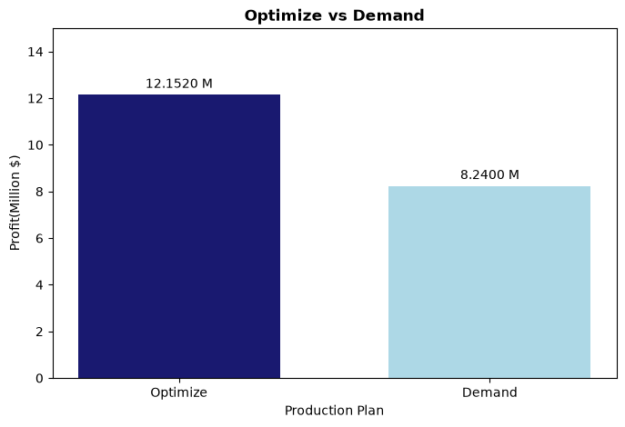

```python
#graph
fig, ax = plt.subplots(figsize=(8, 5))

labels = ['Optimize', 'Demand']
profit = [pulp.value(model.objective)/1000000, profit_demand/1000000]
bar_colors = ['midnightblue','lightblue']
width = 0.65

bars = ax.bar(labels, profit, color=bar_colors, width=width)
ax.bar_label(bars, fmt="%.4f M", padding=3)

ax.set_title(
    "Optimize vs Demand",
    fontweight="bold"
)

ax.set_xlabel("Production Plan")
ax.set_ylabel("Profit(Million $)")
ax.set_ylim(0, 15)

plt.show()
```

The model increases total profit by $3,912,000.